# Project 1: Chess Tournament Results

Turning a formatted text file into a tidy CSV

Author

Aniss Sahraoui

Published

September 25, 2026

# 1 Overview

The file `tournmentinfo.txt` holds the results of a 7-round chess tournament as a formatted text table, the kind meant to be read by a person rather than by software. The goal of this project is to turn it into a CSV file with one row per player and these five columns:

- Player’s name
- Player’s state
- Total number of points
- Player’s pre-tournament rating
- Average pre-tournament rating of the opponents they played

The last column is the interesting one. It is not in the file: each player’s opponents are listed only by pair number, so their ratings have to be looked up and averaged. For the first player, Gary Hua, the expected result is `Gary Hua, ON, 6.0, 1794, 1605`.

# 2 The Raw File

The file is read from my GitHub repository, so this document runs on any machine.

```r
raw_lines <- read_lines(
  "https://raw.githubusercontent.com/AnissSahraoui/DATA607/main/Week4/tournmentinfo.txt"
)

length(raw_lines)
```

```
[1] 196
```

```r
cat(raw_lines[1:7], sep = "\n")
```

```
-----------------------------------------------------------------------------------------
 Pair | Player Name                     |Total|Round|Round|Round|Round|Round|Round|Round|
 Num  | USCF ID / Rtg (Pre->Post)       | Pts |  1  |  2  |  3  |  4  |  5  |  6  |  7  |
-----------------------------------------------------------------------------------------
    1 | GARY HUA                        |6.0  |W  39|W  21|W  18|W  14|W   7|D  12|D   4|
   ON | 15445895 / R: 1794   ->1817     |N:2  |W    |B    |W    |B    |W    |B    |W    |
-----------------------------------------------------------------------------------------
```

The structure repeats every three lines: a row of dashes, then **two lines per player**.

- **First line:** pair number, name, total points, and the seven round results. Each result is a letter and the pair number of the opponent, so `W 39` means a win against player 39.
- **Second line:** state, USCF ID, the pre-tournament rating and post-tournament rating, and the colour played each round.

Three things make the parsing less than routine:

- The two pieces of information for one player sit on **different lines**.
- Opponents are given by **pair number**, so a player’s opponents’ ratings can only be found by looking them up elsewhere in the same file.
- Some rounds are not games against an opponent. A bye or an unplayed round (`H`, `U`, `X`, `B`) has no pair number, so it must not count as a game.

# 3 Parsing

## 3.1 Splitting the file into one row per player

I keep only the data lines, drop the two header lines, and then take the odd-numbered lines as the first line of each player and the even-numbered lines as the second.

```r
data_lines <- raw_lines |>
  keep(\(line) str_detect(line, fixed("|"))) |>   # drop the rows of dashes
  tail(-2)                                        # drop the two header lines

first_lines  <- data_lines[c(TRUE, FALSE)]
second_lines <- data_lines[c(FALSE, TRUE)]

c(data_lines = length(data_lines), players = length(first_lines))
```

```
data_lines    players
       128         64
```

## 3.2 Pulling out each field

Both lines are split on the `|` character, which makes every field a column I can pick by position.

```r
field <- function(lines, i) {
  str_split(lines, fixed("|")) |> map_chr(i) |> str_trim()
}

players <- tibble(
  pair         = as.integer(field(first_lines, 1)),
  name         = str_to_title(field(first_lines, 2)),
  total_points = as.numeric(field(first_lines, 3)),
  state        = field(second_lines, 1),

  # "15445895 / R: 1794   ->1817" or "15142253 / R: 1641P17->1657P24"
  # The pre-rating is the first number after "R:". The "P17" on some ratings marks a
  # provisional rating and is not part of the number, so \\d+ stops before it.
  pre_rating   = field(second_lines, 2) |> str_extract("(?<=R:)\\s*\\d+") |> as.integer(),

  # Fields 4 to 10 of the first line are the seven rounds. Taking the digits gives the
  # opponent's pair number, and gives NA for a bye or an unplayed round.
  opponents    = map(first_lines, \(line) {
    str_split_1(line, fixed("|"))[4:10] |> str_extract("\\d+") |> as.integer()
  })
)

players |> select(pair, name, state, total_points, pre_rating) |> head(5)
```

| pair | name | state | total_points | pre_rating |
| --- | --- | --- | --- | --- |
| 1 | Gary Hua | ON | 6.0 | 1794 |
| 2 | Dakshesh Daruri | MI | 6.0 | 1553 |
| 3 | Aditya Bajaj | MI | 6.0 | 1384 |
| 4 | Patrick H Schilling | MI | 5.5 | 1716 |
| 5 | Hanshi Zuo | MI | 5.5 | 1655 |

## 3.3 Averaging the opponents’ ratings

With every player’s rating in hand, each player’s opponents are looked up by pair number. The average uses only the rounds that were actually played, which is what the project asks for: the ratings are divided by the number of games played.

```r
rating_of <- set_names(players$pre_rating, players$pair)

players <- players |>
  mutate(
    games_played     = map_int(opponents, \(o) sum(!is.na(o))),
    opponent_ratings = map(opponents, \(o) unname(rating_of[as.character(o[!is.na(o)])])),
    avg_opponent_rating = map_dbl(opponent_ratings, mean) |> round()
  )

players |>
  select(name, total_points, pre_rating, games_played, avg_opponent_rating) |>
  head(5)
```

| name | total_points | pre_rating | games_played | avg_opponent_rating |
| --- | --- | --- | --- | --- |
| Gary Hua | 6.0 | 1794 | 7 | 1605 |
| Dakshesh Daruri | 6.0 | 1553 | 7 | 1469 |
| Aditya Bajaj | 6.0 | 1384 | 7 | 1564 |
| Patrick H Schilling | 5.5 | 1716 | 7 | 1574 |
| Hanshi Zuo | 5.5 | 1655 | 7 | 1501 |

# 4 Checking the Results

## 4.1 The example from the project

```r
gary <- players |> filter(pair == 1)

tibble(
  name              = gary$name,
  state             = gary$state,
  total_points      = gary$total_points,
  pre_rating        = gary$pre_rating,
  opponent_ratings  = paste(gary$opponent_ratings[[1]], collapse = ", "),
  games_played      = gary$games_played,
  average           = gary$avg_opponent_rating
)
```

| name | state | total_points | pre_rating | opponent_ratings | games_played | average |
| --- | --- | --- | --- | --- | --- | --- |
| Gary Hua | ON | 6 | 1794 | 1436, 1563, 1600, 1610, 1649, 1663, 1716 | 7 | 1605 |

This matches the project exactly: the same seven opponent ratings, and an average of **1605**.

## 4.2 Checks across all players

```r
check_results <- list(
  n_players            = nrow(players),
  pair_numbers_1_to_64 = identical(players$pair, 1:64),
  missing_values       = sum(is.na(players$name), is.na(players$state),
                             is.na(players$total_points), is.na(players$pre_rating),
                             is.na(players$avg_opponent_rating)),
  states               = paste(sort(unique(players$state)), collapse = ", "),
  rounds_per_player    = paste(range(map_int(players$opponents, length)), collapse = "-"),
  games_played_range   = paste(range(players$games_played), collapse = "-"),
  # every game has two players, so the pair numbers should appear in each other's lists
  games_are_mutual     = {
    games <- players |> select(pair, opponents) |> unnest(opponents) |> drop_na()
    all(map2_lgl(games$pair, games$opponents,
                 \(p, o) p %in% games$opponents[games$pair == o]))
  }
)

tibble(check = names(check_results),
       result = map_chr(check_results, as.character))
```

| check | result |
| --- | --- |
| n_players | 64 |
| pair_numbers_1_to_64 | TRUE |
| missing_values | 0 |
| states | MI, OH, ON |
| rounds_per_player | 7-7 |
| games_played_range | 1-7 |
| games_are_mutual | TRUE |

All 64 players are present with no missing values. The last check is the strongest one: for every game, the two players list each other, which means no opponent number was misread.

## 4.3 Rounds that were not games

Every player has seven rounds, but not everyone played seven games.

```r
players |>
  count(games_played, name = "players") |>
  arrange(desc(games_played))
```

| games_played | players |
| --- | --- |
| 7 | 41 |
| 6 | 13 |
| 5 | 7 |
| 4 | 1 |
| 3 | 1 |
| 1 | 1 |

```r
players |>
  filter(games_played < 7) |>
  select(name, total_points, games_played, avg_opponent_rating) |>
  head(5)
```

| name | total_points | games_played | avg_opponent_rating |
| --- | --- | --- | --- |
| Kenneth J Tack | 4.5 | 6 | 1506 |
| Mike Nikitin | 4.0 | 5 | 1386 |
| Eugene L Mcclure | 4.0 | 6 | 1300 |
| Gaurav Gidwani | 3.5 | 6 | 1222 |
| Chiedozie Okorie | 3.5 | 6 | 1314 |

These players had a bye or an unplayed round. Their average uses only the games they played, so a bye neither counts as an opponent with a rating of zero nor drags the average down.

# 5 The CSV File

```r
tournament_results <- players |>
  mutate(
    # written with one decimal place, so a score of 6 appears as "6.0" as in the project example
    total_points = sprintf("%.1f", total_points)
  ) |>
  select(
    player_name             = name,
    player_state            = state,
    total_points            = total_points,
    player_pre_rating       = pre_rating,
    avg_opponent_pre_rating = avg_opponent_rating
  )

write_csv(tournament_results, "tournament_results.csv")

head(tournament_results, 10)
```

| player_name | player_state | total_points | player_pre_rating | avg_opponent_pre_rating |
| --- | --- | --- | --- | --- |
| Gary Hua | ON | 6.0 | 1794 | 1605 |
| Dakshesh Daruri | MI | 6.0 | 1553 | 1469 |
| Aditya Bajaj | MI | 6.0 | 1384 | 1564 |
| Patrick H Schilling | MI | 5.5 | 1716 | 1574 |
| Hanshi Zuo | MI | 5.5 | 1655 | 1501 |
| Hansen Song | OH | 5.0 | 1686 | 1519 |
| Gary Dee Swathell | MI | 5.0 | 1649 | 1372 |
| Ezekiel Houghton | MI | 5.0 | 1641 | 1468 |
| Stefano Lee | ON | 5.0 | 1411 | 1523 |
| Anvit Rao | MI | 5.0 | 1365 | 1554 |

The file `tournament_results.csv` has 64 rows and 5 columns, and is ready to load into a SQL database. The first line of the file is:

```r
read_lines("tournament_results.csv", n_max = 2) |> cat(sep = "\n")
```

```
player_name,player_state,total_points,player_pre_rating,avg_opponent_pre_rating
Gary Hua,ON,6.0,1794,1605
```

# 6 A Look at the Results

The CSV is the deliverable, but the data answers a couple of questions easily now.

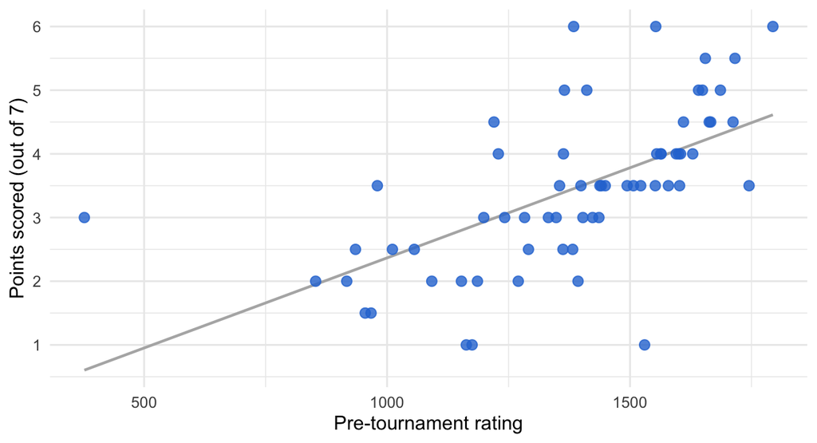

Figure 1: Pre-tournament rating against points scored. Each dot is a player.

```r
ggplot(players, aes(x = pre_rating, y = total_points)) +
  geom_smooth(method = "lm", se = FALSE, color = "grey70", linewidth = 0.8) +
  geom_point(size = 2.6, alpha = 0.8, color = "#2a78d6") +
  scale_y_continuous(breaks = 0:7) +
  labs(x = "Pre-tournament rating", y = "Points scored (out of 7)") +
  theme_minimal(base_size = 12)
```

```r
cor(players$pre_rating, players$total_points) |> round(2)
```

```
[1] 0.61
```

Rating and score are strongly related, as expected, but the fit is far from perfect. The players furthest above the line did better than their rating suggested:

```r
model <- lm(total_points ~ pre_rating, data = players)

players |>
  mutate(expected_points = round(predict(model), 1),
         points_above_expected = round(total_points - expected_points, 1)) |>
  slice_max(points_above_expected, n = 5, with_ties = FALSE) |>
  select(name, pre_rating, total_points, expected_points, points_above_expected)
```

| name | pre_rating | total_points | expected_points | points_above_expected |
| --- | --- | --- | --- | --- |
| Aditya Bajaj | 1384 | 6 | 3.5 | 2.5 |
| Jacob Alexander Lavalley | 377 | 3 | 0.6 | 2.4 |
| Dakshesh Daruri | 1553 | 6 | 3.9 | 2.1 |
| Anvit Rao | 1365 | 5 | 3.4 | 1.6 |
| Stefano Lee | 1411 | 5 | 3.5 | 1.5 |

# 7 Conclusion

The results were checked in three ways: the project’s own example for Gary Hua reproduces exactly, no values are missing for any of the 64 players, and every game appears in both players’ round lists.